# Part II - Prosper Loan Analysis

## by Mattias Johansson

## Investigation Overview

This investigation aims to explore and analyze correlations between the prosper loans and APR that the loan takers will recieve. The parameters of focus is the loan amount, APR (Annual Percentage Rate), loan rate, occupation, loan status, employment status. Other parameters that helped the analysis are income and monthly loan payment.

The end goal is to find an explanation to the APR value and size of the loans in terms to the previously stated parameters

## Dataset Overview

The dataset contains detailed information on 113,937 loans, with 81 different variables recorded for each loan. These variables include the loan amount, the borrower's interest rate, the current status of the loan, the borrower's income, and many other relevant details. Some information was gathered from 2009 and forward, and here we **only** use data that have been provided from 2009 and forward.

## Distribution of the loans

The distribution of the LoanOriginalAmount. The loans take on values from 1k USD to more than 34k USD. When plotting the distrubution on a logarithmic shape we see a multimodal shape.

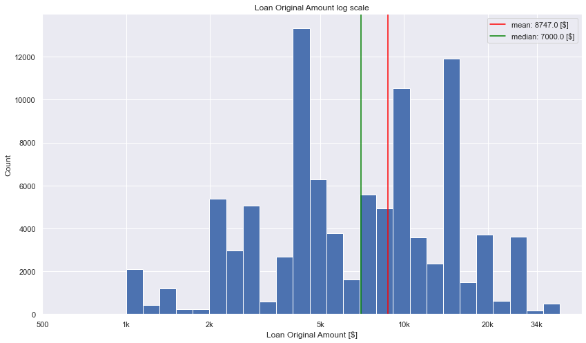

## Distribution of the loans per occupation and employeestatus

The non-informational category "Other" in the "Occupation" variable are among the top loan takers in this dataset. The category Professional, Computer programmer, Executive, Teacher and Analyst are among the top 5 loan takers.

[figure not shown]

[figure not shown]

## Distribution of the loans for the most uncommon loan takers

The mean loan of the least occuring employment statuses is 5528 while the median is 4000.

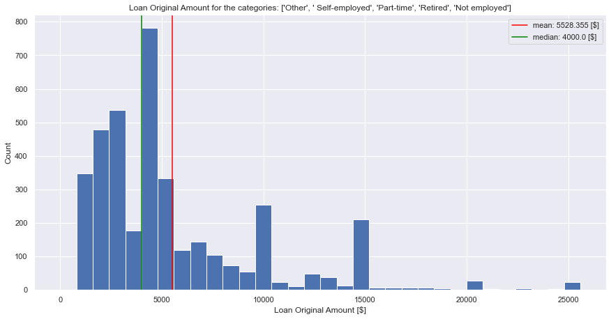

## Distribution of the loans for the most common loan takers

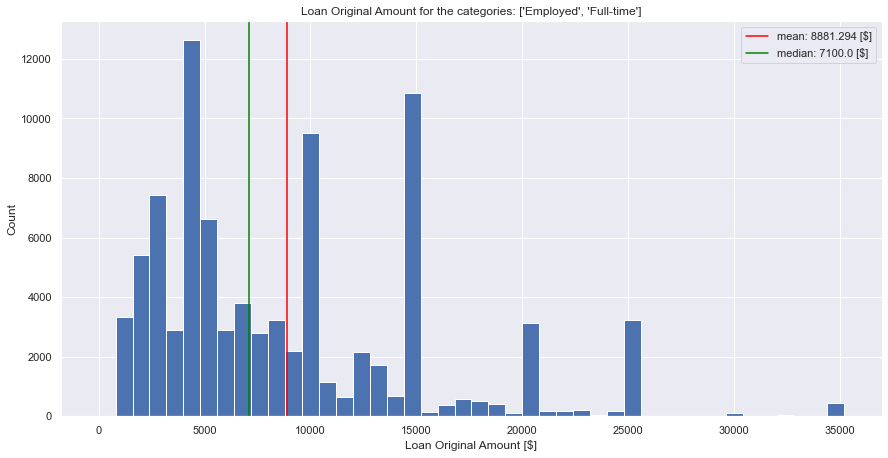

## Income range and APR in relation to montly loan payment

In general, people that earn more also have a lower APR.

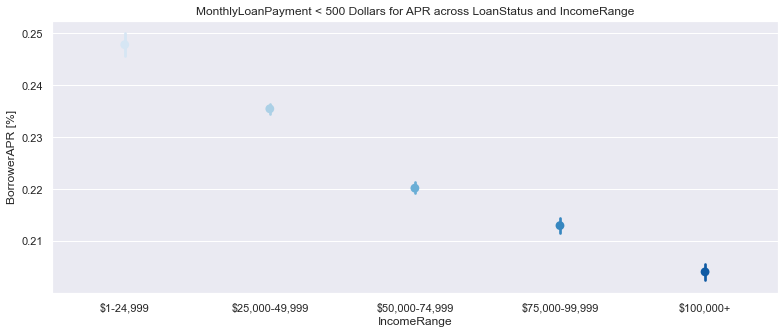

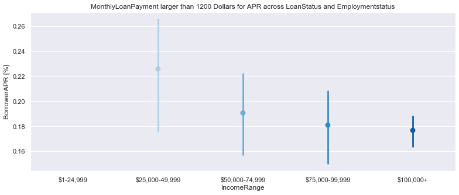